# 📊 **SI 618 - Homework #3: Data Visualization**

**Version:** 2024.09.19.3.CT

Welcome to **Homework #3**! In this assignment, you will be exploring data visualization techniques using `Pandas`, `Seaborn`, and `Matplotlib`. Let’s dive into the world of data and transform insights into impactful visuals! 🎨📈

### 📋 **Homework Assignment Overview:**

In this homework assignment, we will be exploring 5-year estimates for **Occupation for the Civilian Employed Population (16 Years and Older)** from the **American Community Survey (ACS)** for the State of Michigan, covering the period from **2010 to 2016**.

The teaching team has partially cleaned the data, but you'll need to perform some additional data cleaning and wrangling to prepare it for 📊 **visualization**.

### 🧠 **Key Learning Concepts:**

As you work on this assignment, you will gain knowledge and skills in the following areas:

- **"Visualizations with `Seaborn` and `Matplotlib`"**  
  You will use the `Pandas`, `Seaborn`, and `Matplotlib` libraries to create 📊 **visualizations** of the data.
- **"Learning about the `American Community Survey`"**  
  You will learn about the **American Community Survey (ACS)** and its role in collecting comprehensive data about the U.S. population.
- **"Understanding U.S. Census Data Standardization"**  
  You will explore how the **U.S. Census Bureau** standardizes its data collection processes to ensure consistency and reliability across datasets.

### 🧹 **What You Need to Do:**

1. Perform any necessary data cleaning and wrangling to prepare the dataset for analysis.
2. Create meaningful visualizations using `Seaborn` and `Matplotlib`.
3. Gain **insights** into the **American Community Survey** and **U.S. Census Data Standardization**.

Good luck, and don't forget to leverage the power of data visualization to tell a compelling story! 🎯

### 🏛️ **American Community Survey (ACS):**

The **American Community Survey (ACS)** is an annual survey conducted by the **U.S. Census Bureau**. It collects detailed data on the social, economic, housing, and demographic characteristics of the U.S. population. The survey provides estimates for various characteristics across different geographic levels, including:

- 🌎 **National level**
- 🗺️ **State level**
- 🏘️ **Local level**

The ACS plays a crucial role in helping policymakers, researchers, and public officials understand the needs of communities, allocate resources, and make informed decisions based on comprehensive data.

For more detailed information about the ACS, visit the [official ACS page](https://www.census.gov/programs-surveys/acs).

🔍 **Census Data Standardization:**

- The U.S. Census Bureau collects data using standardized techniques and predefined "areas" to ensure consistency and comparability across different datasets. The geographic defined go as follows:
  - **State**: A primary division of the United States.
  - **County**: A sub-division of a state.
  - **Tract**: A small, relatively permanent statistical subdivision of a county.
  - **Block Group**: A subdivision of a tract, consisting of a group of blocks.
  - **Block**: The smallest geographic unit used by the Census Bureau.

  For full reference, please review the following link: [Census Geographic Boundaries](https://learn.arcgis.com/en/related-concepts/united-states-census-geography.htm)

For a visual reference, please reveiw the following photo:

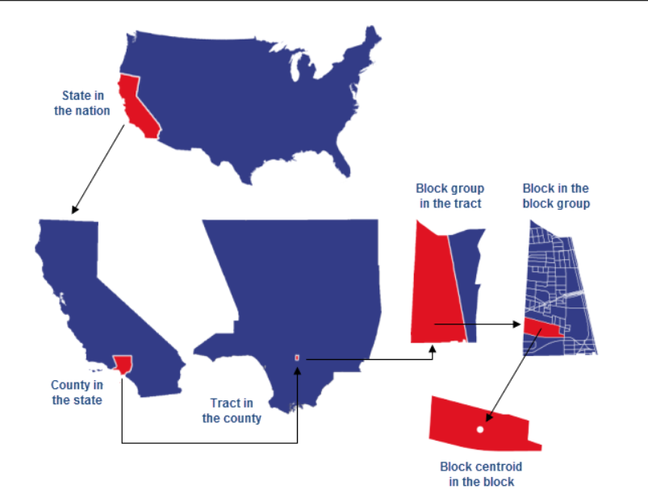

### 🚀 **Your Challenge:**

A major challenge for you in this assignment is to **devise a plan** for tackling each question. While the questions outline the overall goals—and some hints are provided—you'll need to think critically about the following:

- **What data do you need** to answer each question?
- **What preprocessing steps** are required to clean and prepare the data for analysis?

You may need to perform additional data wrangling to get the data into the right form for 📊 **visualization**. Keep in mind that a well-thought-out approach will help you uncover insights and create effective visual representations. 🔍

### 📝 **Grading Rubric:**

Each question is worth the same number of points:

- 🎯 **90-100%**: Correct and complete answer. Code follows [PEP 8](https://www.python.org/dev/peps/pep-0008/) guidelines, includes a well-written interpretation in Markdown, and contains no spelling or grammar errors. Minor issues like formatting or missing names may slightly reduce the score.
- 🛠️ **75-85%**: Mostly correct, with two or fewer noticeable errors or omissions. Minor stylistic flaws in code or interpretation.
- ⚠️ **50-70%**: Significant omissions or errors. Noticeable deviations from PEP 8 or moderate spelling/grammar issues.
- 🚧 **25-45%**: Incomplete or incorrect answer with substantial parts missing.
- 🛑 **0 points**: Question not attempted.

**NOTE**: You are only permitted to use the pandas, Seaborn, and matplotlib libraries for creating 📊 visualizations in this assignment. You may use other libraries for other purposes, but you may not use them to create 📊 visualizations.

### 🛠️ **Let’s Start with Our Usual Imports:**

First, let’s import the necessary libraries. You may need to import additional modules depending on how you choose to tackle each question.

##### Additional imports might be needed for specific tasks

```python
import pandas as pd
import seaborn as sns
import matplotlib.pyplot as plt
import numpy as np
import os
```

Let's start by reading in the data. You will need to load the data from the provided CSV files

**Note: The GSIs have provided the below code block to streamline the data loading process. You can use this code as a starting point for your data loading.**

### 📂 **Loading the Data:**

Let’s start by reading in the data from the provided CSV files.

**Note:** The GSIs have provided the code block below to help streamline the data loading process. You can use this as a starting point for your data loading.

```python
# The teaching team has provided some starter code to load the datasets
# Our Expectation is that you follow along and understand the code

"""
DESC: Load all CSV files from a directory into individual variables

PARAMS:
    my_path: str - The path to the directory containing the CSV files

RETURNS:
    tuple - A tuple containing the DataFrames for each CSV file
"""
def load_data_from_dir(my_path):
    """Load all CSV files from a directory into individual variables."""

    # Create an empty list to store the the data frames
    dataframes = []

    # Use list comprehension to get the filenames of all the CSVs in the directory
    filenames = sorted([f for f in os.listdir(my_path) if f.endswith('.csv')])

    # Loop through the filenames and read each CSV into a DataFrame
    for filename in filenames:
        df = pd.read_csv(os.path.join(my_path, filename))
        dataframes.append(df)

    # Return the dataframes as a tuple
    return tuple(dataframes)


# Load the data
# variable assignment known as tuple unpacking
acs_2010, acs_2011, acs_2012, acs_2013, acs_2014, acs_2015, acs_2016 = \
    load_data_from_dir("Occupation_Data")

# You may need to change the my_path argument to the directory where your CSV files are located ^^^
```

```python
# Create a list of dataframes for easier manipulation
dataframes = [acs_2010, acs_2011, acs_2012, acs_2013, acs_2014, acs_2015, acs_2016]

# Loop through the data frames and print the dims of each

for i, df in enumerate(dataframes):
    print(f"acs_{2010 + i}: {df.shape}")
```

```
acs_2010: (2813, 8)
acs_2011: (2813, 8)
acs_2012: (2813, 8)
acs_2013: (2813, 8)
acs_2014: (2813, 8)
acs_2015: (2813, 8)
acs_2016: (2813, 8)
```

## 🟢 **Q0:**

Please show your understanding of the above code by finishing the following fill in the blanks:

- How many CSV files from the American Community Survey were provided? 7
  - **Note: specifically referencing the number of American Community Survey files for Occupation not including the Income CSV**
- Each file is loaded from my Occupation_Data directory.
- The data is returned as a tuple.

## 🟢 **Q1: Data Preparation for Visualization**

The data format is as follows:

- 📅 **7 DataFrames**: One for each year from 2010 to 2016.
- 📊 **Same Structure**: Each DataFrame contains the same columns but represents different years.
- 🏙️ **Census Tracts**: Each row (observation) represents a census tract in this version of the American Community Survey.

### 🔑 **Features (Columns) of the Datasets**:

- 🗺️ **Geography**: The name of the census tract.
- 🆔 **Geographic Area Name**: The unique identifier for the census tract.
- 👥 **Total**: The total number of employed civilians above the age of 16 in the census tract.
- 💼 **Management, Business, Science, and Arts Occupations**: Percentage of employed civilians in this category.
- 🛠️ **Service Occupations**: Percentage of employed civilians in this category.
- 🏢 **Sales and Office Occupations**: Percentage of employed civilians in this category.
- 🏗️ **Natural Resources, Construction, and Maintenance Occupations**: Percentage of employed civilians in this category.
- 🚚 **Production, Transportation, and Material Moving Occupations**: Percentage of employed civilians in this category.

The data in each of the columns (with the exclusion of `Geography`, `Geographic Area Name` and `Total`) is a percentage formatted as a whole number (i.e., 24.6 == 0.246). We suggest that you use these percentages and the `Total` column to calculate the number of employed civilians over the age of 16 in each occupation category for each census tract.

### 🟢 **Steps to Prepare the Data for 📊 Visualization:**

1. **Add a `year` column**:  
   Take the data from each year and add a new column called `year` to each dataframe that contains the year of the data.
2. **Combine the dataframes**:  
   Row bind the dataframes together into a single dataframe and call it `combined_df`.
3. **Calculate employment numbers**:  
   Calculate the number of employed civilians in each occupation category for each census tract by multiplying the percentage by the `Total` column.

#### 💡 **Hints:**

- You can use the `pd.concat()` function to row bind the dataframes together.
- Check out this helpful Stack Overflow post for an explanation of what **Row Bind** means:  
  [Row Bind](https://stackoverflow.com/questions/14988480/pandas-version-of-rbind)
- Inspect the `dtypes` of the columns in the combined dataframe to ensure you're working with appropriate data types for 📊 visualizations and calculations.
- The dataframe column names are quite long. You might want to **rename** them for easier access. Think back to the Pandas lecture on renaming columns using a dictionary.

```python
acs_2010.columns
```

```
Index(['Geography', 'Geographic Area Name', 'Total',
       'Management, business, science, and arts occupations',
       'Service occupations', 'Sales and office occupations',
       'Natural resources, construction, and maintenance occupations',
       'Production, transportation, and material moving occupations'],
      dtype='object')
```

```python
# Adding the year column to each of the dataframe
for i, df in enumerate(dataframes):
    df["year"] = 2010 + i
    df.columns = ['Geography', 'Area', 'Total', 'MBSA_pct',
                  'Service_pct', 'Office_pct', 'Natural_pct', 'Production_pct', 'year']
```

```python
# Concatenate all the dataframes into a single dataframe
combined_df = pd.concat(dataframes)
```

```python
# Calculate the employment numbers in each
occupation_list = ['MBSA', 'Service', 'Office', 'Natural', 'Production']
combined_df['Total'] = combined_df['Total'].astype(int) # Convert the total to integer and the occupation percentage to float
for occupation in occupation_list:
    combined_df[occupation + '_pct'] = combined_df[occupation + '_pct'].str.replace('-', '0') # replace the missing data with 0
    combined_df[occupation + '_pct'] = combined_df[occupation + '_pct'].astype(float)
    combined_df[occupation] = combined_df['Total'] * combined_df[occupation +'_pct'] /100
```

```python
combined_df.head(5)
```

|  | Geography | Area | Total | MBSA_pct | Service_pct | Office_pct | Natural_pct | Production_pct | year | MBSA | Service | Office | Natural | Production |
| --- | --- | --- | --- | --- | --- | --- | --- | --- | --- | --- | --- | --- | --- | --- |
| 0 | 1400000US26001000100 | Census Tract 1, Alcona County, Michigan | 517 | 24.6 | 16.8 | 26.1 | 15.3 | 17.2 | 2010 | 127.182 | 86.856 | 134.937 | 79.101 | 88.924 |
| 1 | 1400000US26001970100 | Census Tract 9701, Alcona County, Michigan | 881 | 29.6 | 24.9 | 22.2 | 13.2 | 10.1 | 2010 | 260.776 | 219.369 | 195.582 | 116.292 | 88.981 |
| 2 | 1400000US26001970400 | Census Tract 9704, Alcona County, Michigan | 1089 | 18.5 | 21.6 | 21.6 | 16.4 | 21.9 | 2010 | 201.465 | 235.224 | 235.224 | 178.596 | 238.491 |
| 3 | 1400000US26001970500 | Census Tract 9705, Alcona County, Michigan | 627 | 21.4 | 20.7 | 25.5 | 12.0 | 20.4 | 2010 | 134.178 | 129.789 | 159.885 | 75.240 | 127.908 |
| 4 | 1400000US26001970600 | Census Tract 9706, Alcona County, Michigan | 386 | 22.0 | 20.7 | 24.9 | 10.4 | 22.0 | 2010 | 84.920 | 79.902 | 96.114 | 40.144 | 84.920 |

### 🟢 **Q2: Filtering and Visualization**

Using the newly created `combined_df` DataFrame, filter the data to include only following counties: `Wayne`, `Oakland`, `Macomb`, and `Washtenaw`.

#### 🔄 **Process**:

1. Filter the data for the selected counties.
2. Create a 📊 **visualization** that shows the **total number of employed civilians** for the selected counties by year.
   - The **x-axis** should represent the year.
   - The **y-axis** should represent the total number of employed civilians.

#### 💡 **Hints**:

- You will need to group the data by year and **sum the total number of employed civilians** for the selected counties.
- Since the data consists of **census tracts** and not individual counties, you need to **aggregate all census tracts** belonging to the selected counties.
- The `Geographic Area Name` column contains a **delimiter (",")** that can be used to split the column into components. Use the `str.split()` function to help with filtering.
- You can use the `groupby()` function to **aggregate the data by year**.

```python
# Extract the county names from Area column
combined_df['County'] = combined_df['Area'].str.split(', ').str[1]
```

```python
# Check the unique county names
combined_df['County'].unique()
```

```
array(['Alcona County', 'Alger County', 'Allegan County', 'Alpena County',
       'Antrim County', 'Arenac County', 'Baraga County', 'Barry County',
       'Bay County', 'Benzie County', 'Berrien County', 'Branch County',
       'Calhoun County', 'Cass County', 'Charlevoix County',
       'Cheboygan County', 'Chippewa County', 'Clare County',
       'Clinton County', 'Crawford County', 'Delta County',
       'Dickinson County', 'Eaton County', 'Emmet County',
       'Genesee County', 'Gladwin County', 'Gogebic County',
       'Grand Traverse County', 'Gratiot County', 'Hillsdale County',
       'Houghton County', 'Huron County', 'Ingham County', 'Ionia County',
       'Iosco County', 'Iron County', 'Isabella County', 'Jackson County',
       'Kalamazoo County', 'Kalkaska County', 'Kent County',
       'Keweenaw County', 'Lake County', 'Lapeer County',
       'Leelanau County', 'Lenawee County', 'Livingston County',
       'Luce County', 'Mackinac County', 'Macomb County',
       'Manistee County', 'Marquette County', 'Mason County',
       'Mecosta County', 'Menominee County', 'Midland County',
       'Missaukee County', 'Monroe County', 'Montcalm County',
       'Montmorency County', 'Muskegon County', 'Newaygo County',
       'Oakland County', 'Oceana County', 'Ogemaw County',
       'Ontonagon County', 'Osceola County', 'Oscoda County',
       'Otsego County', 'Ottawa County', 'Presque Isle County',
       'Roscommon County', 'Saginaw County', 'St. Clair County',
       'St. Joseph County', 'Sanilac County', 'Schoolcraft County',
       'Shiawassee County', 'Tuscola County', 'Van Buren County',
       'Washtenaw County', 'Wayne County', 'Wexford County'], dtype=object)
```

```python
# Filter the data for the selected counties
select_counties = ['Wayne County', 'Oakland County', 'Macomb County', 'Washtenaw County']
selected_df = combined_df[combined_df['County'].isin(select_counties)]
```

```python
# Check the unique county names of the selected data
selected_df['County'].unique()
```

```
array(['Macomb County', 'Oakland County', 'Washtenaw County',
       'Wayne County'], dtype=object)
```

```python
total_employment = selected_df.groupby(['year', 'County'])['Total'].sum().reset_index()
```

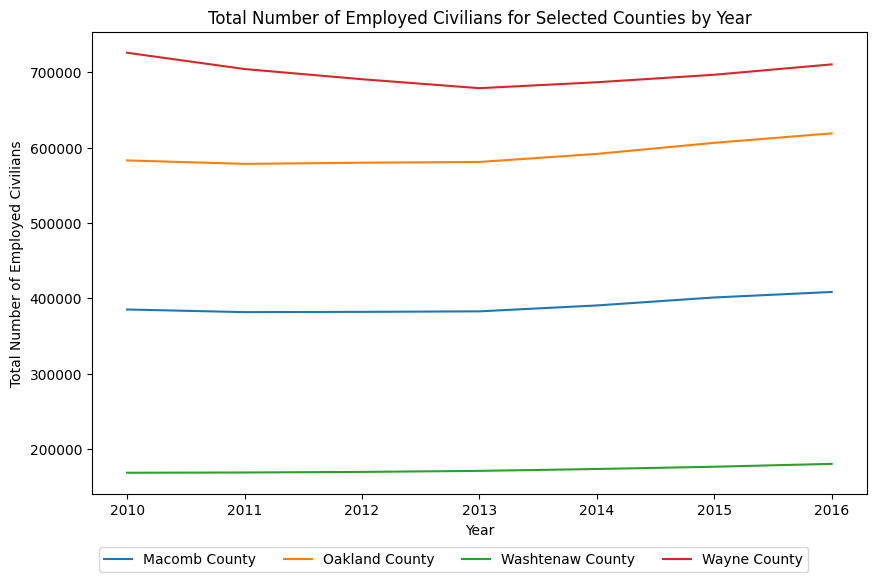

```python
# Create a visualization that shows the total number of employed civilians
# for the selected counties by year.
# x axis as year, y axis as the number
plt.figure(figsize=(10, 6))
sns.lineplot(x='year', y='Total', hue='County', data=total_employment)
plt.legend(bbox_to_anchor=(0, -0.1), loc='upper left', ncol = 4)
plt.xlabel('Year')
plt.ylabel('Total Number of Employed Civilians')
plt.title('Total Number of Employed Civilians for Selected Counties by Year')
plt.show()
```

### 🟢 **Q3: Occupation Category Visualization for 2016**

Create a 📊 **visualization** that shows the number of employed civilians in each occupation category for the most recent year, **2016**, in the following counties:  
`St. Clair`, `Macomb`, `Oakland`, `Lapeer`.

#### 🔄 **Process**:

1. Filter the data for the selected counties.
2. Limit the data to the **year 2016** (using logical indexing).
3. Create a 📊 **visualization** that shows the number of employed civilians in each occupation category for these counties.

#### 💡 **Hint**:

- Use **logical indexing** to limit the data to **2016**.
- Filter for the counties of interest using `.isin()`. You can find the documentation for `.isin()` [here](https://pandas.pydata.org/docs/reference/api/pandas.DataFrame.isin.html).

```python
# Filter the data to the selected counties for Q3
counties_q3 = ['St. Clair County', 'Macomb County', 'Oakland County', 'Lapeer County']
selected_q3_df = combined_df[combined_df['County'].isin(counties_q3)]
```

```python
# Limit the data to the year 2016 with logical indexing
selected_q3_df_2016 = selected_q3_df[selected_q3_df['year'] == 2016]
```

```python
selected_q3_df_2016.head(5)
```

|  | Geography | Area | Total | MBSA_pct | Service_pct | Office_pct | Natural_pct | Production_pct | year | MBSA | Service | Office | Natural | Production | County |
| --- | --- | --- | --- | --- | --- | --- | --- | --- | --- | --- | --- | --- | --- | --- | --- |
| 923 | 1400000US26087330000 | Census Tract 3300, Lapeer County, Michigan | 1520 | 26.4 | 18.9 | 18.5 | 15.1 | 21.1 | 2016 | 401.280 | 287.280 | 281.200 | 229.520 | 320.720 | Lapeer County |
| 924 | 1400000US26087330500 | Census Tract 3305, Lapeer County, Michigan | 1336 | 26.1 | 19.9 | 18.9 | 14.1 | 21.0 | 2016 | 348.696 | 265.864 | 252.504 | 188.376 | 280.560 | Lapeer County |
| 925 | 1400000US26087331000 | Census Tract 3310, Lapeer County, Michigan | 676 | 20.0 | 16.0 | 26.2 | 19.4 | 18.5 | 2016 | 135.200 | 108.160 | 177.112 | 131.144 | 125.060 | Lapeer County |
| 926 | 1400000US26087331500 | Census Tract 3315, Lapeer County, Michigan | 1062 | 28.1 | 11.8 | 25.1 | 13.7 | 21.4 | 2016 | 298.422 | 125.316 | 266.562 | 145.494 | 227.268 | Lapeer County |
| 927 | 1400000US26087332000 | Census Tract 3320, Lapeer County, Michigan | 2442 | 26.9 | 18.4 | 26.0 | 14.0 | 14.7 | 2016 | 656.898 | 449.328 | 634.920 | 341.880 | 358.974 | Lapeer County |

[figure not shown]

```python
# Create a bar chart that shows the number of employed civilians
# in each employment category for the selected counties in 2016.
# x axis as the employment category, y axis as the number
plt.figure(figsize=(10, 6))

# Create a grouped bar chart
occupation_columns = ['MBSA', 'Service', 'Office', 'Natural', 'Production']

# Group the data by county and sum the employment numbers
selected_q3_df_2016.groupby('County')[occupation_columns].sum().plot(kind='bar', figsize=(10, 6))

# Adding titles and labels
plt.title('Percentage of Employed Civilians by Occupation and County (2016)')
plt.xlabel('County')
plt.ylabel('Percentage of Employed Civilians')
plt.xticks(rotation=0)
plt.legend(title='Occupation Category')
plt.tight_layout()
plt.show()
```

### 🟢 **Q4: Distribution of Employed Civilians (2013)**

For all counties in the dataset for the year **2013**, create a 📊 **visualization** that shows the distribution of the total number of employed civilians across all counties.

#### 🔄 **Steps**:

1. **Create a density plot** to visualize the distribution of the total number of employed civilians.
2. After examining the density plot, you’ll notice some census tracts have very high numbers of employed civilians.
   - Create a **second density plot** that **excludes census tracts** with more than **1,250 employed civilians**.

#### ⚠️ **Note**:

- You may notice **values below 0** in the density plot, which is likely due to the **noise** introduced by the American Community Survey.
- Here is a link to learn more about this: [Census Noise in Data](https://www2.census.gov/programs-surveys/cbp/technical-documentation/methodology/noise-data.pdf).
- You don't need to filter out these values, but make a comment on whether you should or should not include them in your visualization.

#### 💡 **Hint**:

- Use the `sns.kdeplot()` function from the Seaborn library to create the density plots.
- For reference, here is a formal definition of a **density plot**: A density plot is a graph that shows the distribution of a continuous variable, such as a numeric variable over time. It's a smooth curve that's often used as an alternative to a histogram

```python
# Aggregate the total number of employed civilians of all counties in 2013
total_employment_all_2013 = combined_df[combined_df['year'] == 2013].groupby('County')['Total'].sum().reset_index()
```

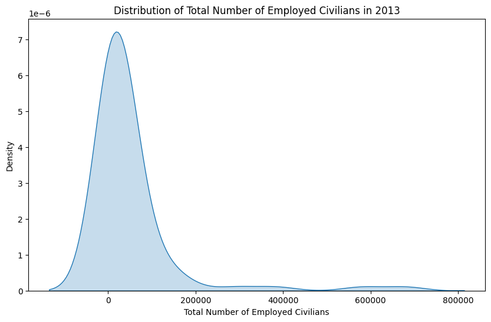

```python
# Create a density plot to visualize the distribution of the total number of employed civilians
plt.figure(figsize=(10, 6))
sns.kdeplot(data=total_employment_all_2013['Total'], fill=True)
plt.title('Distribution of Total Number of Employed Civilians in 2013')
plt.xlabel('Total Number of Employed Civilians')
plt.ylabel('Density')
plt.show()
```

The density plot suggests there might be some negative outliers in the data. Double check the histogram to see if this is the case.

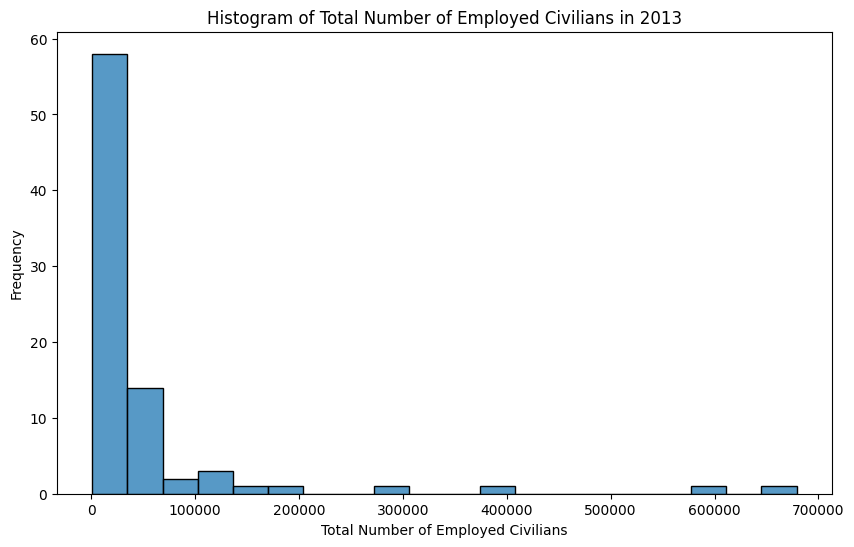

```python
# Draw the histogram of the total number to double check the possible negative values
plt.figure(figsize=(10, 6))
sns.histplot(data=total_employment_all_2013['Total'], bins=20)
plt.title('Histogram of Total Number of Employed Civilians in 2013')
plt.xlabel('Total Number of Employed Civilians')
plt.ylabel('Frequency')
plt.show()
```

No negative values were found.

```python
# Create a second kde plot without tracts that above 1250 employed civilians
## filter the data to remove the tracts with more than 1250 employed civilians
filtered_df_2013 = combined_df[(combined_df['year'] == 2013) & (combined_df['Total'] <= 1250)]
```

```python
# Double check the filtered data
filtered_df_2013.describe()
```

|  | Total | MBSA_pct | Service_pct | Office_pct | Natural_pct | Production_pct | year | MBSA | Service | Office | Natural | Production |
| --- | --- | --- | --- | --- | --- | --- | --- | --- | --- | --- | --- | --- |
| count | 1169.000000 | 1169.000000 | 1169.000000 | 1169.000000 | 1169.000000 | 1169.000000 | 1169.0 | 1169.000000 | 1169.000000 | 1169.000000 | 1169.000000 | 1169.000000 |
| mean | 778.137725 | 25.174423 | 22.606843 | 22.913858 | 7.882977 | 15.684773 | 2013.0 | 218.295023 | 175.474455 | 189.836761 | 65.831189 | 128.646574 |
| std | 343.127481 | 14.862315 | 11.727869 | 9.480572 | 5.762562 | 8.691264 | 0.0 | 160.841649 | 94.508928 | 101.030537 | 52.896407 | 83.590881 |
| min | 0.000000 | 0.000000 | 0.000000 | 0.000000 | 0.000000 | 0.000000 | 2013.0 | 0.000000 | 0.000000 | 0.000000 | 0.000000 | 0.000000 |
| 25% | 560.000000 | 16.000000 | 15.400000 | 18.600000 | 3.500000 | 9.800000 | 2013.0 | 97.050000 | 117.549000 | 120.870000 | 22.880000 | 65.394000 |
| 50% | 846.000000 | 24.000000 | 21.700000 | 23.400000 | 7.300000 | 15.700000 | 2013.0 | 201.168000 | 170.090000 | 193.620000 | 57.860000 | 121.800000 |
| 75% | 1056.000000 | 32.200000 | 28.700000 | 28.300000 | 11.700000 | 21.200000 | 2013.0 | 301.602000 | 231.012000 | 258.552000 | 97.244000 | 179.676000 |
| max | 1249.000000 | 100.000000 | 100.000000 | 100.000000 | 42.900000 | 48.500000 | 2013.0 | 999.460000 | 690.976000 | 527.436000 | 337.554000 | 482.589000 |

```python
# Group by the county and sum up the total employment number
total_employment_all_2013_filtered = filtered_df_2013.groupby('County')['Total'].sum().reset_index()
```

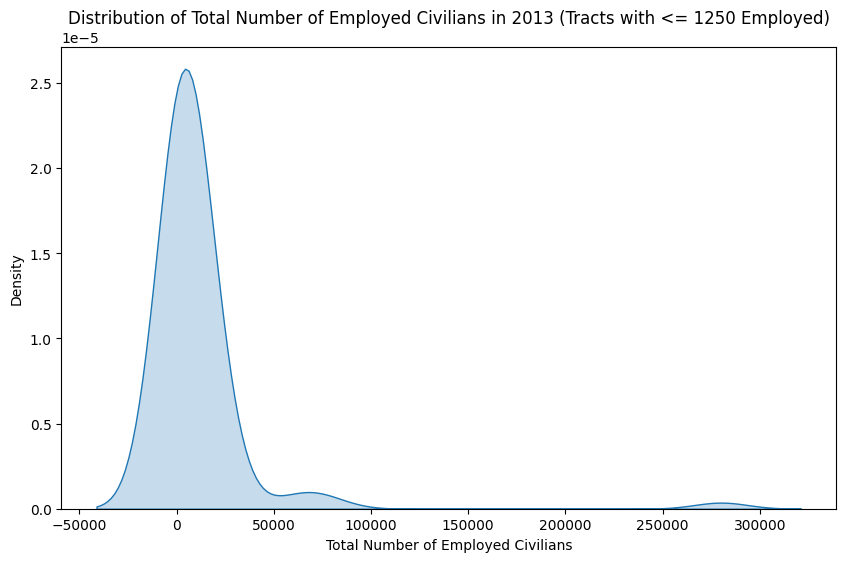

```python
# Create a density plot to visualize the distribution of the total number of
# employed civilians without the tracts with more than 1250 employed civilians
plt.figure(figsize=(10, 6))
sns.kdeplot(data=total_employment_all_2013_filtered['Total'], fill=True)
plt.title('Distribution of Total Number of Employed Civilians in 2013 (Tracts with <= 1250 Employed)')
plt.xlabel('Total Number of Employed Civilians')
plt.ylabel('Density')
plt.show()
```

### 🟢 **Q5: Census Tracts by County (2016)**

Write code to find the **number of census tracts by county** for the year **2016**. Once you have the counts, choose **5 counties** to visualize that are in **Southeast Michigan**.

#### 🔄 **Process**:

1. Find the **number of census tracts** by county for 2016.
2. Choose **5 counties** from the list below:
   - `Wayne`, `Oakland`, `Macomb`, `Washtenaw`, `Livingston`, `St. Clair`, `Lapeer`, `Monroe`, `Genesee`.
3. Create a 📊 **visualization** to show the number of census tracts for the selected counties. In your visulization sort the selected counties alphabetically

#### 🗺️ **Reference**:

For reference, here’s a map of the State of Michigan:

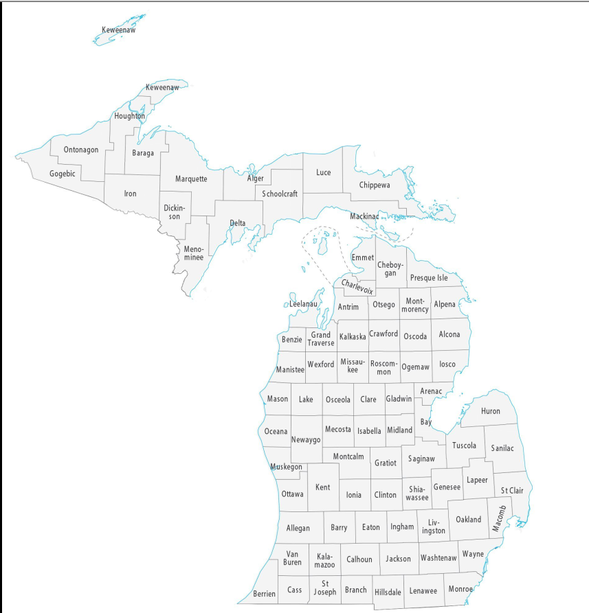

#### 💡 **Hint**: You can use a bar plot to visualize the number of census tracts by county

```python
# Calculate the number of census tracks in each county in 2016
census_tracks_2016 =\
    combined_df[combined_df['year'] == 2016].groupby('County')['Area'].count().reset_index()
```

```python
census_tracks_2016
```

|  | County | Area |
| --- | --- | --- |
| 0 | Alcona County | 6 |
| 1 | Alger County | 4 |
| 2 | Allegan County | 25 |
| 3 | Alpena County | 10 |
| 4 | Antrim County | 8 |
| ... | ... | ... |
| 78 | Tuscola County | 14 |
| 79 | Van Buren County | 16 |
| 80 | Washtenaw County | 100 |
| 81 | Wayne County | 611 |
| 82 | Wexford County | 8 |

83 rows × 2 columns

[figure not shown]

```python
# Create a bar chart to visualize the number of census tracks in each county in 2016
southeast_counties = ['Wayne County', 'Oakland County', 'Macomb County',
                      'Washtenaw County', 'Livingston County']
southeast_tracks_2016 = census_tracks_2016[census_tracks_2016['County'].isin(southeast_counties)]

plt.figure(figsize=(10, 6))
sns.barplot(x='County', y='Area', data=southeast_tracks_2016)
plt.title('Number of Census Tracks in Each County in 2016')
plt.xlabel('Number of Census Tracks')
plt.ylabel('County')
plt.show()
```

### 🟢 **Q6: Histogram of Employed Civilians (2016)**

Create a **histogram** that shows the distribution of the total number of employed civilians across all counties for the year **2016**.

#### 🔄 **Steps**:

1. Create a **histogram** to visualize the distribution of employed civilians.
2. Experiment with the `bins` argument:
   - Produce **two histograms** with **different bin sizes** to see how it affects the look of the distribution.
3. **Comment** on why you chose one bin size over the other.

This task will help you understand how bin size impacts the visualization of distribution! 🎨📊

```python
# Aggregate the total number of employed civilians of all counties in 2016
total_employment_all_2016 =\
    combined_df[combined_df['year'] == 2016].groupby('County')['Total'].sum().reset_index()
```

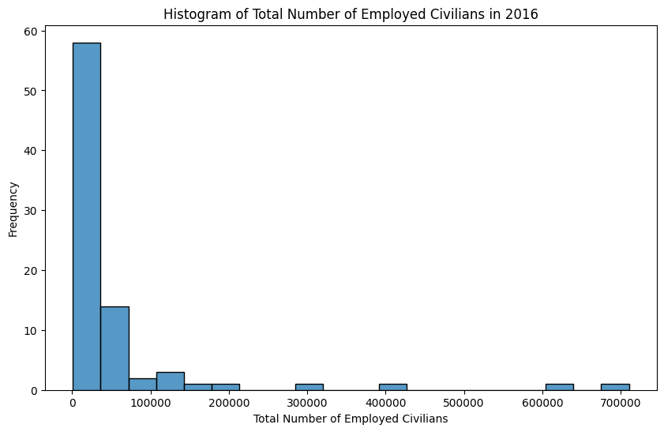

```python
# Create a histogram to visualize the distribution of the number of employed civilians in 2016
plt.figure(figsize=(10, 6))
sns.histplot(data=total_employment_all_2016['Total'], bins=20) # set the bin size to 20
plt.title('Histogram of Total Number of Employed Civilians in 2016')
plt.xlabel('Total Number of Employed Civilians')
plt.ylabel('Frequency')
plt.show()
```

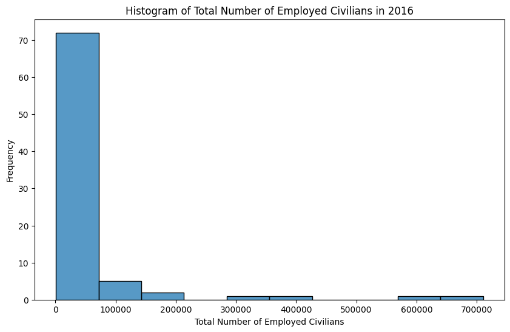

```python
# Create a histogram to visualize the distribution of the number of employed civilians in 2016
plt.figure(figsize=(10, 6))
sns.histplot(data=total_employment_all_2016['Total'], bins=10) # set the bins to 10
plt.title('Histogram of Total Number of Employed Civilians in 2016')
plt.xlabel('Total Number of Employed Civilians')
plt.ylabel('Frequency')
plt.show()
```

I would prefer the histogram that has 20 bins. It provides a more detailed view of the distribution of employed civilians espeicially in the range of 0 to 200000.

### 🟢 **Q7: Occupational Category Visualization (2012)**

Create a 📊 **visualization** that shows the **average number of employed civilians** in each occupational category by county for the year **2012**.

#### 🔄 **Steps**:

1. Show the values as a **percentage** of the total number of employed civilians in each county.
   - Create a **100% stacked bar plot** to represent this data.
2. Only include the following counties from **Southeast Michigan**:
   - `Wayne`, `Oakland`, `Macomb`, `Washtenaw`, `Livingston`, `St. Clair`, `Lapeer`, `Monroe`, `Genesee`.

#### 💡 **Hints**:

- Use the `groupby()` function to aggregate data by county.
- To visualize this effectively, consider using a **100% stacked bar plot**. For a reference, check out this [link](https://www.statisticshowto.com/stacked-bar-chart/).

This question will help you practice data aggregation and visualize percentages in a clear, impactful way! 🎨📊

```python
# Group by county and aggregate the mean of the number of employed civilians in each county in 2012
## Then create a 100% stacked bar chart to visualize the percentage of
## employed civilians in each occupation category for each county in 2012
mean_employment_2012 =\
    combined_df[combined_df['year'] == 2012].groupby('County')[occupation_columns].mean()

## Calculate the percentage for each occupation category
percentage_employment_2012 =\
    mean_employment_2012.div(mean_employment_2012.sum(axis=1), axis=0) * 100
```

```python
# Double check the percentages
percentage_employment_2012.head(5)
```

| County | MBSA | Service | Office | Natural | Production |
| --- | --- | --- | --- | --- | --- |
| Alcona County | 24.491398 | 23.462781 | 23.371601 | 13.316343 | 15.357877 |
| Alger County | 26.183212 | 25.926686 | 19.846382 | 12.820065 | 15.223654 |
| Allegan County | 28.107293 | 15.750281 | 23.121439 | 11.607832 | 21.413156 |
| Alpena County | 31.316344 | 17.636466 | 25.307481 | 10.470495 | 15.269214 |
| Antrim County | 26.844274 | 21.655979 | 22.445283 | 12.774199 | 16.280265 |

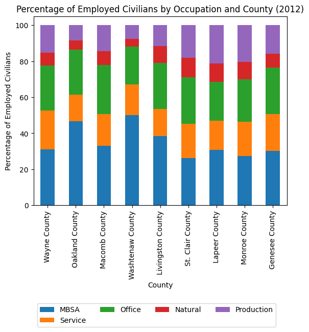

```python
southeast_counties_q7 = ['Wayne County', 'Oakland County', 'Macomb County',
                         'Washtenaw County', 'Livingston County', 'St. Clair County',
                         'Lapeer County', 'Monroe County', 'Genesee County']

## Create the 100% stacked bar chart
plt.figure(figsize=(10, 6))
percentage_employment_2012.loc[southeast_counties_q7].plot(kind='bar', stacked=True)
plt.title("Percentage of Employed Civilians by Occupation and County (2012)")
plt.xlabel("County")
plt.ylabel("Percentage of Employed Civilians")
plt.legend(bbox_to_anchor=(0, -0.5), loc='upper left', ncol = 4)
```

### 🟢 **Q8: High vs. Low Earning Census Tracts (2015)**

#### 🔄 **Steps**:

1. **First Visualization**:
   - Show the distribution for **all counties** in the dataset.
2. **Second Visualization**:
   - Repeat the process, but only for the following counties:
     - `Wayne`, `Oakland`, `Macomb`, `Washtenaw`.

#### 💡 **Hint**:

- You’ll need to **join the median income dataset for 2015** with the employment dataset for 2015.
- Recall our previous in-class exercise on joining datasets. Consider:
  - **What type of join** is appropriate for this task?
  - **What column** should you join on?

This task will help you practice dataset merging and visualize the economic distribution in different regions. 📊💡

```python
# Import the income dataset for 2015
income_df = pd.read_csv('Income_Data/acs_2015_median_inc.csv')
```

```python
# filter the employment dataset for 2015
employment_df = combined_df[combined_df['year'] == 2015]
```

```python
# inner join the two datasets on the geography code column
merge_df = pd.merge(employment_df, income_df, on='Geography')
merge_df['Median Income'].info()
```

```
<class 'pandas.core.series.Series'>
RangeIndex: 2813 entries, 0 to 2812
Series name: Median Income
Non-Null Count  Dtype
--------------  -----
2813 non-null   object
dtypes: object(1)
memory usage: 22.1+ KB
```

```python
def process_income(income):
    """Convert the income to integer and handle the missing values."""
    income = income.replace(',', '').replace('-','')
    try:
        return int(income)
    except:
        return np.nan
```

```python
# process the median income column
merge_df['Median Income'] = merge_df['Median Income'].apply(process_income)
```

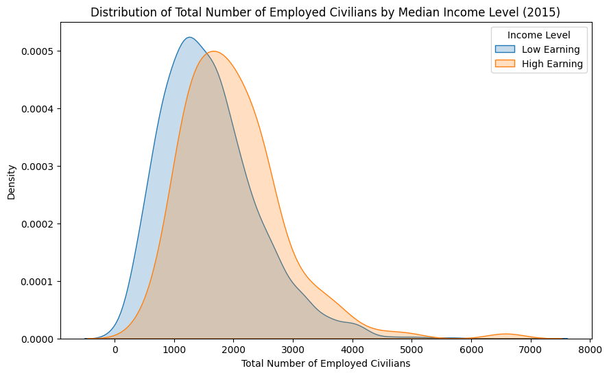

```python
# Plot the distribution of total number of employed civilians in low income tracts and high income tracts
plt.figure(figsize=(10, 6))
sns.kdeplot(data=merge_df[merge_df['Median Income'] < 50000]['Total'], label='Low Earning', fill=True)
sns.kdeplot(data=merge_df[merge_df['Median Income'] >= 50000]['Total'], label='High Earning', fill=True)
plt.title('Distribution of Total Number of Employed Civilians by Median Income Level (2015)')
plt.xlabel('Total Number of Employed Civilians')
plt.ylabel('Density')
plt.legend(title='Income Level')
plt.show()
```

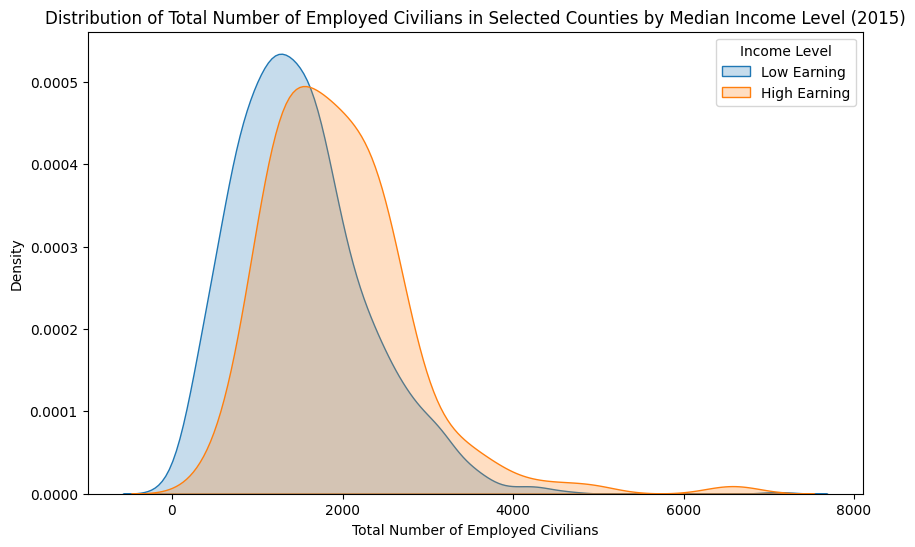

```python
# Plot the same distribution in Wayne, Oakland, Macomb, Washtenaw counties
select_counties = ['Wayne County', 'Oakland County', 'Macomb County', 'Washtenaw County']
merge_selected_df = merge_df[merge_df['County'].isin(select_counties)]
plt.figure(figsize=(10, 6))
sns.kdeplot(data=merge_selected_df[merge_selected_df['Median Income'] < 50000]['Total'], label='Low Earning', fill=True)
sns.kdeplot(data=merge_selected_df[merge_selected_df['Median Income'] >= 50000]['Total'], label='High Earning', fill=True)
plt.title('Distribution of Total Number of Employed Civilians in Selected Counties by Median Income Level (2015)')
plt.xlabel('Total Number of Employed Civilians')
plt.ylabel('Density')
plt.legend(title='Income Level')
plt.show()
```

### 🟢 IMPORTANT: Final Checks

Before you submit your homework, please ensure that:

- Your complete homework **runs without errors** from top to bottom.  
  💡 **Tip**: Use the **Run All** feature to quickly check this.

## 📤 Submission Instructions

Submit your completed assignment in both of the following formats:

1. **.IPYNB** (Jupyter Notebook format)
2. **.HTML** (Webpage format)

Upload your files to **Canvas** before the deadline.